# SAT solver evaluation

```r
library("tidyverse")
```

# Measurement

We measured all combinations of the accepted options by the solver on random 3-SAT formulas with variable counts 50, 75, 100 and 125.

```r
results <- read_csv("results.csv", col_types = "-nnnn-lfffln")
```

# DPLL Algorithm

Here are the average solve durations in milliseconds for the basic DPLL version of the solver. We can see that the algorithm’s time complexity is near exponential as expected.

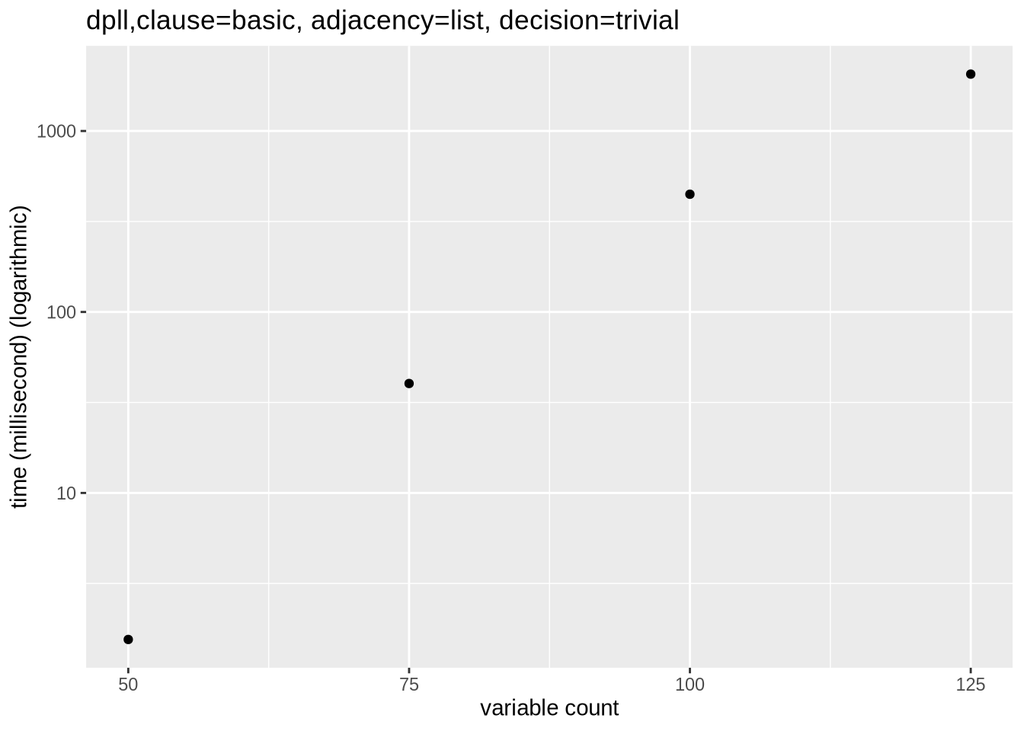

```r
results_ <- results %>%
    filter(!cdcl, adjacency == "list", clause == "basic", decision == "trivial") %>%
    group_by(var) %>%
    summarize(solve = mean(solve))

ggplot(results_, aes(x = var, y = solve)) +
    geom_point() +
    scale_x_continuous(name = "variable count", breaks = seq(50, 125, 25)) +
    scale_y_log10(
        name = "time (millisecond) (logarithmic)") +
    ggtitle("dpll,clause=basic, adjacency=list, decision=trivial")
```

We also tried the solver on non random instances.

```r
read_csv("results-nonrandom.csv", col_types = "-nnnn-nc")
```

| solve | decisions | unit | visit | var | name |
| --- | --- | --- | --- | --- | --- |
| 0 | 57 | 326 | 8959 | 61 | ais6 |
| 124 | 17979 | 146627 | 5646446 | 113 | ais8 |
| 0 | 18 | 361 | 7031 | 116 | blocksworld_medium |
| 0 | 24 | 66 | 630 | 90 | flat1 |
| 0 | 25 | 65 | 630 | 90 | flat2 |
| 18 | 11460 | 52518 | 447846 | 42 | phole6 |
| 405 | 208174 | 1087482 | 10365248 | 56 | phole7 |
| 6972 | 3230428 | 17743702 | 188767170 | 72 | phole8 |
| 215955 | 87327026 | 533260662 | 6205876880 | 90 | phole9 |

# Watched Literals

We compare the solve time and the number of visited clauses between adjacency lists and watched literals.

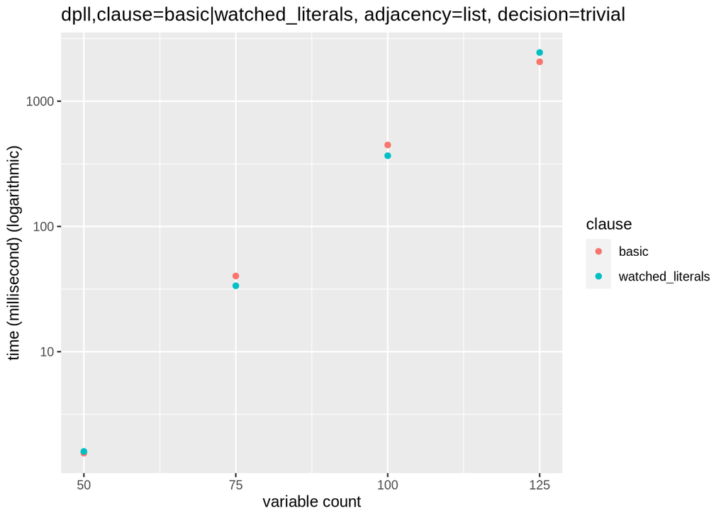

```r
results_ <- results %>%
    filter(!cdcl, adjacency == "list", clause != "counting", decision == "trivial") %>%
    group_by(var, clause) %>%
    summarize(solve = mean(solve), visit = mean(visit), .groups = "keep")

plot <- ggplot(results_, aes(x = var, color = clause)) +
    ggtitle("dpll,clause=basic|watched_literals, adjacency=list, decision=trivial") +
    scale_x_continuous(name = "variable count", breaks = seq(50, 125, 25))

plot +
    geom_point(aes(y = solve)) +
    scale_y_log10(name = "time (millisecond) (logarithmic)")
```

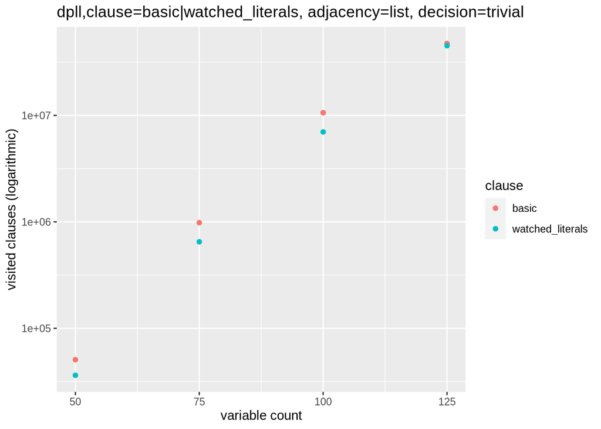

```r
plot +
    geom_point(aes(y = visit)) +
    scale_y_log10(name = "visited clauses (logarithmic)")
```

# CDCL

We compare the parameters using formulas with 125 variables.

```r
results_ <- results %>%
    filter(cdcl, var == 125) %>%
    group_by(var, clause, adjacency, decision) %>%
    summarize(solve = mean(solve), .groups = "keep") %>%
    arrange(solve)

results_
```

| var | clause | adjacency | decision | solve |
| --- | --- | --- | --- | --- |
| 125 | watched_literals | set_unordered | JW_static | 37.75 |
| 125 | watched_literals | list | JW_static | 38.45 |
| 125 | watched_literals | set | JW_static | 45.30 |
| 125 | watched_literals | set_unordered | VSIDS | 53.85 |
| 125 | watched_literals | list | VSIDS | 62.35 |
| 125 | basic | set_unordered | JW_static | 64.55 |
| 125 | basic | list | JW_static | 69.60 |
| 125 | watched_literals | set | VSIDS | 73.80 |
| 125 | basic | set | JW_static | 77.95 |
| 125 | basic | list | VSIDS | 110.75 |

[output cut: 26 more lines]

Our solver performs best when it uses watched literals for unit propagation, uses hashsets for keeping the adjacent clauses and uses the static variant of the JW heuristic.

Interesting is the result when the solver doesn’t use WL, uses just a list for adjacency but uses the well suiting JW heuristic. Then the result is worse than the best result by just a factor of 1.84.

# Decision Heuristics

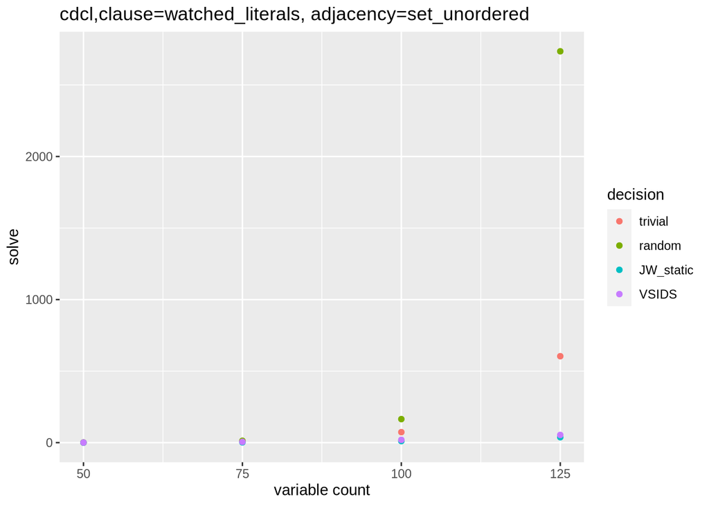

```r
results_ <- results %>%
    filter(cdcl, adjacency == "set_unordered", clause == "watched_literals") %>%
    group_by(var, decision) %>%
    summarize(solve = mean(solve), .groups = "keep")

plot <- ggplot(results_, aes(x = var, color = decision)) +
    geom_point(aes(y = solve)) +
    scale_x_continuous(name = "variable count", breaks = seq(50, 125, 25))

plot +
    ggtitle("cdcl,clause=watched_literals, adjacency=set_unordered")
```

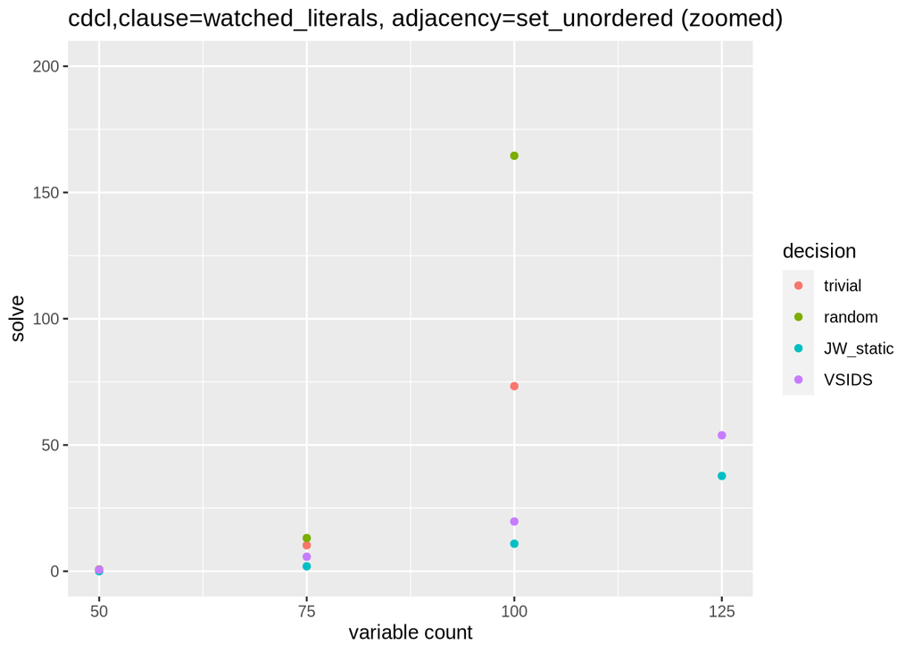

```r
plot +
    ggtitle("cdcl,clause=watched_literals, adjacency=set_unordered (zoomed)") +
    scale_y_continuous(limits = c(0, 200))
```

We can see that the sophisticated heuristics perform much better than the random and trivial ones. The JW heuristic seems to consistently outperform VSIDS in our solver.

We also observe that although with better heuristics the time complexity doesn’t change, the factor by which the solving time increses is much smaller. The ratio of heuristic performances between the random and the JW heuristic changes from around 7 at 75 variables to 70 at 125 variables.

# N Queens Puzzle

We modelled the N queens puzzle problem as a SAT instance. For generating the CNF formula the program `PPsat-queens-generate` is used. We also implemented a script named `PPsat-queens.sh` which uses a solver passed as an argument and prints all models for the queens puzzle for a certain size of the board.

The tested solvers are ours (PPsat), CaDiCaL and Glucose.

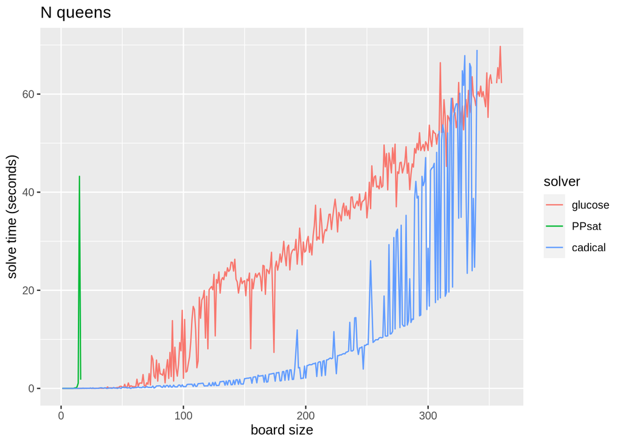

```r
results <- read_csv("results-queens.csv", col_types = "nfi")

plot <- ggplot(results, aes(x = size, y = time, color = solver)) +
    geom_line() +
    scale_y_continuous(name = "solve time (seconds)", limits = c(0, 70))

plot +
    scale_x_continuous(name = "board size") +
    ggtitle("N queens")
```

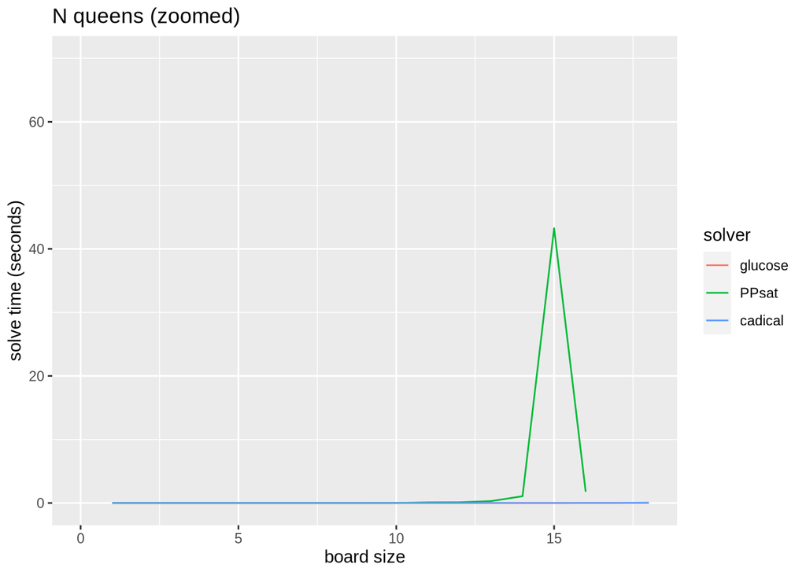

```r
plot +
    scale_x_continuous(name = "board size", limits = c(0, 18)) +
    ggtitle("N queens (zoomed)")
```

# Cryptarithms

We implemented a program named `PPsat-crypt-generate` which converts a cryptarithm into an SMT instance in the SMT-LIB format. We then implemented the script `PPsat-crypt.sh` which uses said generator and an SMT solver to print all models of the problem.

To solve the long cryptarithm from the assignment it takes around 16 seconds with solver z3. This time includes the checking of the uniqueness of the model.